# probvslikelihood

## Probability vs Likelihood

Just a short explanation to explain the difference between the two.

Virtually all of the explanation, and even the examples, has been taken from [this youtube video](https://www.youtube.com/watch?v=pYxNSUDSFH4) (great channel).

```python
import matplotlib.pyplot as plt
import numpy as np
import pandas as pd
import seaborn as sns
from scipy.stats import norm
```

First, create an array of normally distributed random numbers. To match the video linked above, use a mean of 32 with a standard distribution of 2.5, the location and shape of the distribution. A sample of 10,000 should be more than enough for what we're trying.

```python
np.random.seed(101)
x = np.random.normal(loc = 32, scale = 2.5, size = 10000)
```

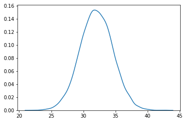

```python
axs = sns.kdeplot(x)
```

Easy enough. We see our data centered at around 32 and most of the data falling within 3 standard deviations ($3 \times 2.5 = 7.5$) of the mean. We'll use examples from this plot to compare probability and likelihood.

### Probability

What is the probability a randomly selected observation from this distribution will be between 32 and 34?

A bit more formally, $p(32 < x < 34 \; | \; mean = 32\; and \;sd = 2.5) = \;?$

Well, it's just the area under the curve between 32 and 34. Probability is between 0 and 1, and the full area under the curve is 1. We just need the proportion that falls between 32 and 34. It's no different than splitting up a pie.

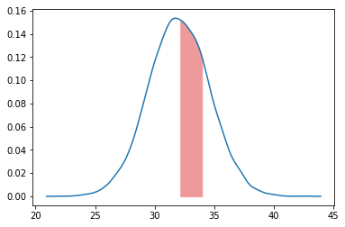

```python
kde_x, kde_y = axs.lines[0].get_data()

axs.fill_between(kde_x, kde_y, where=(np.logical_and(kde_x<34, kde_x>32)) ,
                interpolate=False, color='#EF9A9A')

axs.figure
```

OK, that's the nice picture, but what's the actual area/probability?

We can use `scipy.stats.norm.cdf` to figure it out. We want to take the area under the curve for everything below 34, then subtract off the area of the curve below 32. The remainder will be everything from 32 to 34. In R, we use `pnorm()` to accomplish the same thing.

```python
norm.cdf(34, loc = 32, scale = 2.5) - norm.cdf(32, loc = 32, scale = 2.5)
```

```
0.28814460141660336
```

So, the *probability* that a randomly selected number from a normal distribution with mean 32 and standard deviation 2.5 will be between 32 and 34 is about 29% Or,

$p(32 < x < 34 \; | \; mean = 32\; and \;sd = 2.5) = \;0.29$

When we talk about probabilities, we're talking about a distribution that is described by the mean and standard deviation (the "given that" in the equation above). The area of the curve is described by $32 < x < 34$. So, using the exact same distribution, if we want to find the probability of a new area, we just change the $32 < x < 34$ to some other range.

##### Verifying the probability

Well, above we've already created the variable `x`, which is 10,000 randomly generated numbers from a similar distribution. Of the 10,000, a rough 2,900 should be between 32 and 34.

```python
len(x[np.logical_and(x>32,x<34)])
```

```
2847
```

Looks to be right on what we'd expect!

##### A few more examples

```python
1 - norm.cdf(37, loc = 32, scale = 2.5)
```

```
0.02275013194817921
```

A little over 2%.

Finally, **what is the probability that a randomly selected number from this distribution will be less than 30?**

```python
norm.cdf(30, loc = 32, scale = 2.5)
```

```
0.2118553985833967
```

OK, about 21%. It's just the entire area of the curve to the left of the x value we choose, which is what norm.cdf returns anyway.

### Likelihood

To talk about likelihood, *assume* you have already selected a number from the distribution.

$L(mean = 32\; and \;sd = 2.5 | \; x = 34\; ) = \; ?$

Our left side is flipped. To get an answer here, we need the height of our curve when x = 34, not an area.

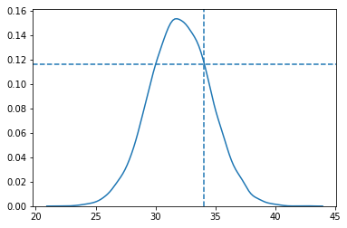

```python
linedat = pd.DataFrame([[34,0.12]], columns = ['x','y'])
sns.kdeplot(x)
plt.axvline(34, linestyle = '--')
axs = plt.axhline(norm.pdf(34, 32, 2.5), linestyle = '--')
```

```python
norm.pdf(34, 32, 2.5)
```

```
0.1158766211045931
```

The likelihood that the number 34 came from a distribution with mean 32 and standard deviation 2.5 is a little under 12%. The same function is available in R: `dnorm()`

$L(mean = 32\; and \;sd = 2.5 | \; x = 34\; ) = \; 0.116$

So, with likelihood, the *measurements* are fixed. We already know that x = 34. We want to know how likely it is that it came from a distribution with the location/shape of our distribution (the mean/sd).

### Summary

Probabilities are the areas under a fixed distribution.

$p(data \; | \; distribution \; )$

Likelihoods are the y-axis values for fixed data points with distributions that can be moved.

$L(distribution \; | \; data \; )$